# Your Digest for Friday, Sep 15, 2023 11:59 PM

> - Increased incidence of metabolic syndrome
> - Muscle weakness mainly due to hypokalemia

[output not shown]

> [!INFO] Epidemiology of Cushing's syndrome and disease  
> **Women** are x3 to x8 time more likely than men to have Cushing's *disease*.  
> and x4 times more likely to have Cushing's syndrome due to adrenal tumour.

> > Males had a three times greater incidence of the ectopic ACTH syndrome 30 years ago, but the increasing incidence of lung cancer in cigarette-smoking females has narrowed that margin

```
1. Corticotroph tumours ~~are not resistant~~ retrain sensitivity to negative FB by glucocorticoids
2. Ectopic ACTH producing tumours have *absolutely no inhibition* from glucocorticoids. (with the exception of some *pulmonary* neuroendocrine tumours)
```

> [!INFO] Hypokalemia in Cushing's syndrome
> - Hypertension and hypokalemia are particular prevalent in ectopic ACTH induced Cushing's syndrome.
> - Normally, the kidney deactivates cortisol via the enzyme 11-beta-dehydrogenase isozyme 2 to inactive cortisone, thus 'protecting' it's mineralocorticoid receptors from the effects of cortisol. [Source](https://pubmed.ncbi.nlm.nih.gov/8370136/)
> - In ectopic ACTH mediated Cushing's syndrome, this inactivation is overwhelmed and cortisol acts on the aldosterone receptors -> producing hypokalemia.

[figure not shown]

[[2021-Basic Sciences#Haemochromatosis (HH)]]

#2021SBR-NOV Q21

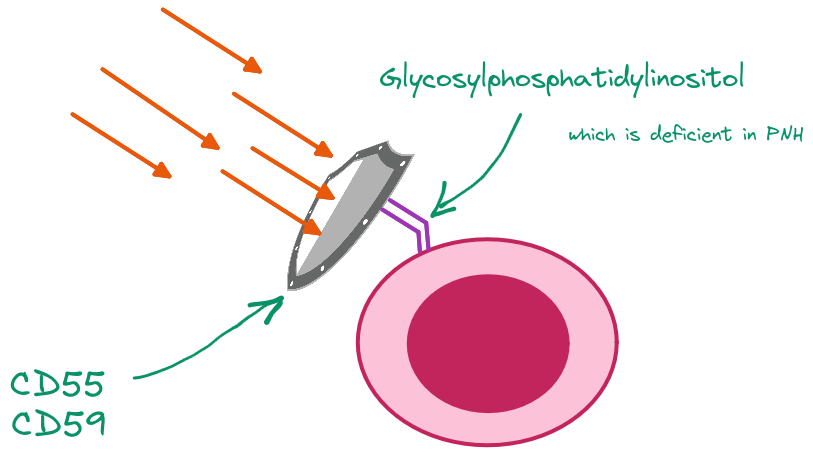

> [!INFO] Clinical triad  
> chronic, *intravascular*, haemolysis  
> venous thrombosis  
> bone marrow failure. (even as severe as aplastic anaemia)

**Acquired** disease (but presents in 30s and 40s) -> a red cell clonal population with the gene mutation develops.  
Mutation of PIG-A gene causing reduced expression of PIG-A protein.  
It anchors complement resisting proteins (CD55 and CD59) which protect the red cell against complement.  
Loss of this function leads to leads to chronic complement mediated haemolysis, more pronounced at night during hypoxia.

The relative importance of each of the 3 complement pathways in the pathogenesis of PNH isn't known yet. [Source](https://www.ncbi.nlm.nih.gov/pmc/articles/PMC4383744/)

- Haemosiderinuria
- Pancytopenia due to marrow suppression (aplastic anaemia)
- venous and arterial *thrombosis* (due to complement activation.)
- Free Hb -> removes nitric oxide from smooth muscle -> smooth muscle contraction ->
  - Dysphagia
  - Pulmonary hypertension. (50% of patients have elevated NT-pro BNP due to ? RV strain - [Source](https://www.ebmt.org/sites/default/files/migration_legacy_files/document/EBMT%20Practical%20Guides%20for%20Nurses_Paroxysmal%20Nocturnal%20Haemaglobinuria%20%28PNH%29_UK.pdf)
  - *myelofibrosis*  
    **Diagnosis**: flow cytometry : CD59 and CD55 negative cells. Old test was the Ham test (demonstration of lysis of RBC at low pH)  
    For some reason, measurement of complement levels is not mentioned in the diagnosis.  
    **Management**:
- Bone marrow transplantation is definitive treatment.
- Drugs - Eculizmab (C5 blocker - prevents lysis)
- Anticoagulation - warfarin.

> [!INFO] Specific gravity and osmolality are proportional and change in the same direction.

> ENAC - 3% <<-- The site of most of the **regulation** of Na absorption
6. **Angiotensin** acts **directly** on the *proximal tubules* to increase Na and bicarconate HCO3 reabsorption.

## Inclusion and exclusion criteria for thrombolysis:

mnemonic for exclusion criteria:

- History, Head CT, Haematology and Clinical.

No the footnote about **potentially disabling defects!**

[figure not shown]

#autosomal-Recessive  
- High Hepcidin reduces iron deposition in RET. Therefore, in HH, iron deposition occurs first in parenchymal tissue and then in RET. (opposite of *transfusional* iron overload)

- One of the most common disorders in **european** people.
- Most common presentation nowadays is elevated ferritin. (i.e incidental biochemical abnormality)
- Skin hyperpigmentation - "bronze skin".
- Arthropathy: " indistinguishable from calcium pyrophosphate crystal deposition disease". Hand joints are often affected.

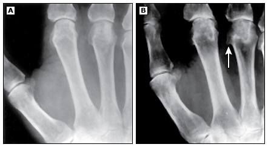

[output not shown]

## Investigations HH

Iron studies -> ferritin and transferrin saturation will be elevated. This is required even when the mutation is found because the disease is known to have low penetrance.

HFE genetic testing;

*MRI* can quantify liver / cardiac iron if ferritin is > 1000 ng/mL

Liver biopsy is not needed for the diagnosis of HH but can be useful to determine the presence of cirrhocis, extent of fibrosis and to exclude other causes of cirrhocis.

## Management of HH

Very simple - Phlebotomy !

[figure not shown]

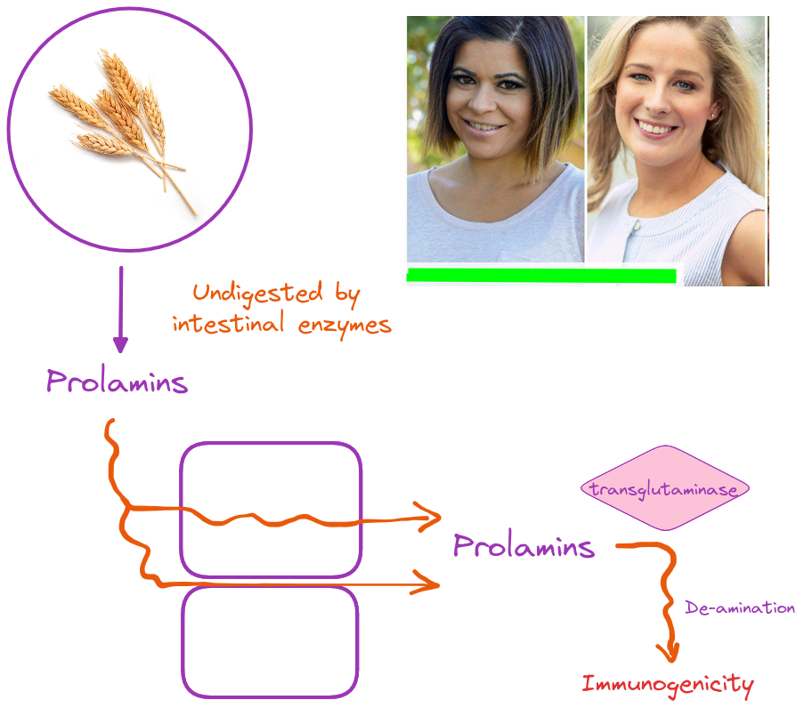

- The disease process results in **crypt hyperplasia and villous atrophy**.

## Symptoms

Most commonly asymptomatic; but patients will show signs of malabsorption.  
Many and will be diagnosed upon evaluation for macrocytic anaemia. (due to malabsorption).  
Mouth ulcers, angular stomatits.

If symptomatic, diarrhoea, steatorrhoea, abdominal pain and weight loss in severe disease.  
Can present at any age.  
Female predominance. Peak is at 40-50 years.

## Complications

Osteoporosis  
parasaesthesia, ataxia, polyneuropathy.  
Associated with autoimmune diseases: IBD, primary biliary cholangitis, chonic liver disease, ILD, epilepsy.

## Diagnosis:

gold standard: small bowel biopsy.  
Serology is very useful : endomysial and tissue transglutaminase antibodies.

# Pulmonary eosinophilia (PE)

> Pulmonary eosinophilia (PE) is defined as the infiltration of eosinophils into the lung tissue; [Source](https://www.ncbi.nlm.nih.gov/books/NBK470600/)

PE can be divided into primary and secondary based on causes:

| Primary PE | Secondary PE |
| --- | --- |
| Acute eosinophilic pneumonia | [[General Medicine 1#Allergic bronchopulmonary aspergillosis]] |
| Chronic eosinophilic pneumonia | Parasites |
| EGPA | Medications |
| Hypereosinophilic syndrome (HES) | Radiation effects |
|  | Malignancies |

> [!INFO] Commonest cause of pulmonary eosinophilia is parasitic infestation.

**Drugs causing PE**

- NSAIDS, aspirin
- ACE inhibitors
- TMP-SMX
- others

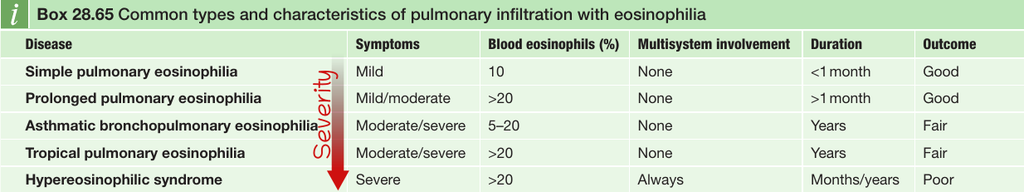

## Loffler syndrome / Loeffler syndrome

#2021SBR-NOV Q13

Also called **simple pulmonary eosinophilia** [Source](https://www.ncbi.nlm.nih.gov/books/NBK470600/)

> - **Acute** (<2 weeks), **mild** ilness(just fever and cough)
> - with **transient pulmonary radiographic opacities** and
> - peripheral blood **eosinophilia** associated with
> - *allergic reaction* to intestinal parasites, commonly described with **Ascariasis and Strongyloidiasis**.

**Resolves spotaneously!**

[figure not shown]

If the course is more prolonged, the disease is called *prolonged pulmonary eosinophilia.*

## Tropical pulmonary eosinophilia (Weingarten syndrome)

[figure not shown]

> [!INFO] The essentials:
> - Tropical pulmonary eosinophilia (TPE) is a hyperresponsive pulmonary syndrome in response to **trapped microfilariae within the lung tissue**
> - characterized by *nocturnal* **cough**, dyspnea, and wheezing.
> - Occurs particularly in young adult males, with a male to female ratio of 4:1 [Source](https://clinmedjournals.org/articles/ijrpm/international-journal-of-respiratory-and-pulmonary-medicine-ijrpm-6-102.php?jid=ijrpm)
> - Diagnosis:
>   - Travel history to a lymphatic filariasis endemic region,
>   - peripheral eosinophilia >3,000/mm3, and
>   - *elevated serum IgE* and *antifilarial antibodies* level is **crucial for diagnosis**.
>   - Extrapulmonary features are present but not very common: #hepatosplenomegaly #lymphadenopathy
> - **Treatment** with **diethylcarbamazine** has an excellent response but untreated, it can case pulmonary fibrosis.
> - [Source](https://www.ncbi.nlm.nih.gov/books/NBK557524/)

# Hypoglycaemic symptoms

Neurogenic (autonomic) symptoms: tremmor, tachycardia, sweating, anxiety, hunger,  
Neuroglycopaenic symptoms: weakness, tiredness, dizziness, poor concentration, inapporriate (even drunken like) behaviour, coma and eath.

Rarely, focal features can occur.

> focal neurological signs, such as **hemiparesis, aphasia, and blindness**

# Management of hypercalcemia

- Mild hypercalcemia Ca < 3 mmol/L : avoid drugs which raise calcium level (lithium carbonate, thiazide diuretics), avoid prolonged bed rest, avoid high calcium diet, avoid dehydration etc.
- Moderate hypercalemia Ca 3 - 3.5 mmol/L: if symptomatic, may need treatment as for severe hypercalcemia. If asymptomatic, can manage as mild hypercalcemia.
- Severe hypercalcemia, simultaneously give the following.
  - IV saline - hypercalcemic patients are usually dehydrated. Fluid replenishment will enhance calcium excretion.
  - S/C calcitonin - for immediate short term management; Begins lowering calcium in 4-6 hours but tachyphylaxis develops after 48 hours. Reduced Ca level by about 0.5 mmol/L. Mechanism: increases renal excretion of Ca and decreases bone resorption by interfering with osteoclast function.
  - Bisphosphonate (usually IV zoledronate) - for longer term control.

> [!TIP] PBC - the C can stand for Cirrhocis or Cholangitis.  
> But Fatigue is a prominent presenting symptom. *Icterus and pruritus are late signs*.
- Presentation: Asymptomatic with #hepatomegaly and **raised ALP**. *(raised ALP is often the only abnormal investigation)*

#2021SBR-NOV Q16

## Epidemiology

3:1 **Female predominance** between 30 to 50 years.

## Pathogenesis

Chronic endothelial damage with IL-2 producing cells migrating into the tissues because of increased expression of adhesion molecules.  
This sets up chronic inflammation leading to a production of a soup of cytokines -> fibroblast activation.

1. Vascular - majority have *Raynaud's phenomemon* <- Seen in almost all, can even precede other symptoms.
2. Fibrogenic - skin changes

## Presentation

Mainly 2 types:  
ANA is positive in 90% of both types.  
RF is positive in 30%.

### Limited cutaneous scleroderma 70%

ACA (anticentromere antibodies) present in most.

- Skin
  - Skin involvement limited to hands, face, feet and forearms.
  - Beak like nose and micostomia
  - Painful digital ulcers.
  - telangiectasiaa nd dilated nail fold capillary loops.
  - Digital ischemia
- Systemic features:
  - GI tract inolvement is common
  - Pulmonary hypertension

### Diffuse cutaneous scleroderma 30%

Antitopoisomerase and anti-RNA polymerase.

Stars with swelling and sclerosis of fingers *rapidly **followed*** by more extensive skin thickening which can involve most of the body.

Early involvement of other organs:

- GI -
  - oesophageal
  - Anal incontinence
  - Dilation of bowel with atony
- Renal

Nearly universal. Thickening of skin of fingers, hands and face are earliest manifestations.  
Digital vasculopathy - **Raynaud's phenomenon - is very common.** Severity of episodes increases over time.  
*Eventually*, ischemic pain -> ulcers -> **necrosis**  
Severe raynauds can be treated with anti vasospasmic agents : CCB, ACEi.

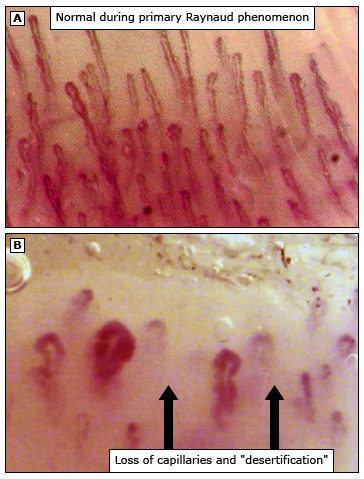

Joint pain, stiffness and **contractures of small and large joints**, tendinits, tendon friction rubs.  
**commonest site of GI involvement: *oesophagus**** -> symptoms are reduced with PPIs.

> [!INFO] Pulmonary involvement accounts for 50% of deaths in these patients.

Bosentan, *warfarin* !? [Source-Warfarin can be used in PAH](https://www.ahajournals.org/doi/10.1161/CIRCOUTCOMES.118.004757) , oxygen, heart lung or lung transplant.  
Pulmonary fibrosis is treated with immunosuupression - clyclophosphamide / azathioprine.

> anticoagulation may be associated with improved survival in idiopathic PAH but may be associated with reduced survival in systemic sclerosis-associated PAH. [Source](anticoagulation may be associated with improved survival in idiopathic PAH but may be associated with reduced survival in systemic sclerosis-associated PAH)
- Used to be the most common cause of death in these patients.

ACEi is the drug of choice for managing hypertension.  
Scleroderma is treated with organ-based symptomatic therapy. There is no cure.  
However, patients with diffuse skin involvement and/or severe inflammatory organ involvement are usually treated with **systemic immunosuppressive therapy**.  
Aporecaeruloplasmin + 6 Cu atoms = ceruloplasmin (the major circulating form of Copper)

> Mutations in *ATP7B* in Wilson disease impair both the incorporation of copper into apoceruloplasmin and the excretion of copper into bile.
> - This **decreased excretion of copper via bile** is what causes Copper accumulation and the disease
> - Impaired incorporation of copper into ceruloplasmin leads to misfolding of the protein and shorter plasma half life. This **reduces serum caeruloplasmin level**.